# Discussion paper for CIE review of the eastern Bering Sea walleye pollock stock assessment

## Spatial modeling of the EBS pollock stock

In development is a spatially disaggregated general model by colleagues at the Auke Bay lab and the University of Alaska, Fairbanks (M. Cheng (2025)). This general model which has flexibility to specify regions and a variety of options including random effects. While this model is not yet fully developed, we present preliminary results here. The model is written in RTMB and is similar to the WHAM model. We pursue this to explore the potential for a more flexible model that can be used for more explicit considerations of stocks linked to different regions (e.g., the US and Russian portions of the EBS). Also, this model to add sex-specificity and random effects (M. L. H. Cheng et al. (2025)).

Figure 32 shows the model results comparing time-varying selectivity whereas Figure 33 shows the model results time series. The difference in the age-1 recruits (Figure 34) is likely due to the fact that the spatial model currently has constant M-at-age compared to the base model.

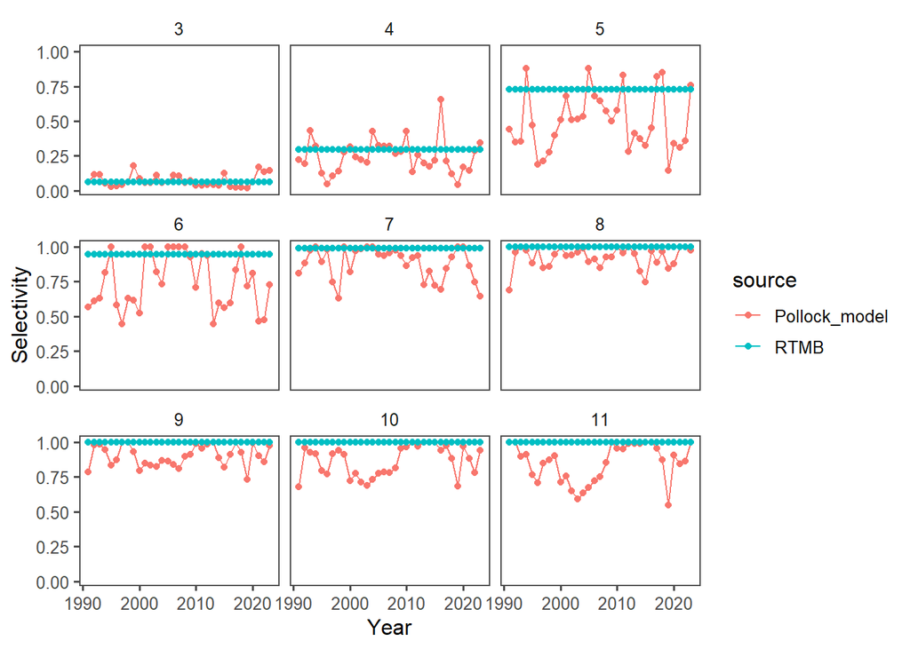

Figure 32: Model results comparing last year’s model with the SPock model.

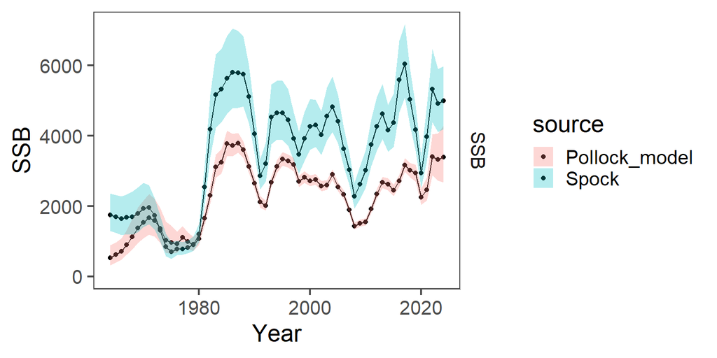

Figure 33: Model results comparing last year’s model with the SPock model.

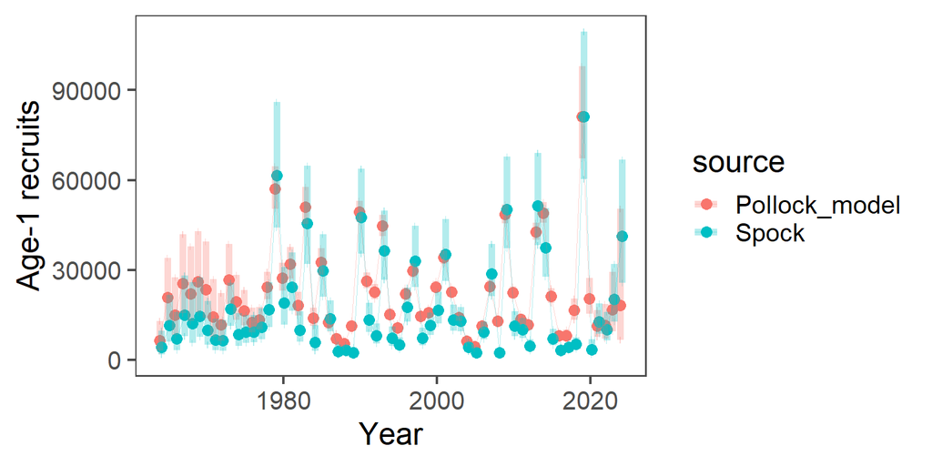

Figure 34: Model results comparing last year’s model with the SPock model.

# Bottom-trawl survey spatial distribution modeling

## Abundance Index Methods

For model-based indices in the Bering Sea, we fitted observations of numerical abundance or biomass per unit area (where the choice of abundance or biomass varied by stock at the request of assessors) from all sampling locations in the 83-112 bottom trawl survey of the EBS, 1982-2025, including:

- Exploratory northern extension samples in 2001, 2005, and 2006
- 83-112 samples available in the NBS in 1982, 1985, 1988, 1991, 2010, 2017-2019, 2021-2023, and 2025

NBS samples collected prior to 2010 and in 2018 did not follow the 20 nautical mile sampling grid that was used in other survey years. Assimilating these unbalanced data requires extrapolating into unsampled areas, facilitated by including a spatially varying response to cold-pool extent (Thorson 2019). This spatially varying coefficient term was estimated for both linear predictors of a delta-model, and detailed comparison of results for EBS pollock has shown that it has a small but notable effect on these indices and resulting stock assessment outputs (O’Leary et al. 2020).

Rather than using the cold-pool covariate for yellowfin sole, we instead used the mean bottom temperature within the inner and middle domain strata from an interpolated temperature product. All models were fitted in the sdmTMB R package (https://pbs-assess.github.io/sdmTMB; Anderson et al. (2022)). All environmental data used as covariates were computed within the coldpool R package (https://github.com/afsc-gap-products/coldpool; Rohan, Barnett, and Charriere (2022)).

We used a spatiotemporal Poisson-link delta-model (Thorson 2018) involving two linear predictors and a gamma distribution to model positive catch rates. We predicted population density across the entire EBS and NBS in each year, using AFSC GAP-approved prediction grids. Spatial and spatiotemporal fields were estimated using a spatial mesh including 250 “knots” whose locations were determined using a K-means algorithm to place the knots evenly over space, in proportion to the dimensions of the prediction grid.

While the prior VAST model was fitted with a 750 knot mesh, we found that sdmTMB models fitted with mesh resolutions from 250-750 knots all provided extremely similar index estimates and that reducing the number of knots dramatically improved computation time. We estimated geometric anisotropy (how spatial autocorrelation declines with differing rates over distance in some cardinal directions than others) and included a spatial and spatiotemporal term for both linear predictors.

To facilitate prediction of density in regions with unsampled years, we specified that the spatiotemporal fields were structured over time as an AR(1) process (where the magnitude of autocorrelation was estimated as a fixed effect for each linear predictor). However, in cases where the AR(1) correlation parameter ⍴ was estimated to be close to 1 for either model component, the model would be collapsed into a simpler structure by specifying ⍴ = 1, i.e., modeling spatiotemporal variation as a random walk. We did not include any temporal correlation for intercepts, which we treated as fixed effects for each linear predictor and year. Finally, we used epsilon bias-correction to correct for retransformation bias (Thorson and Kristensen 2016).

We checked model fits for convergence by confirming that the derivative of the marginal likelihood with respect to each fixed effect was sufficiently small (less than ~ 0.001) and that the Hessian matrix was positive definite, along with other model checks produced by the function `sdmTMB::sanity()`. We then checked goodness of model fit by computing Dunn-Smyth randomized quantile residuals (Dunn and Smyth 1996) and visualizing these using a quantile-quantile plot within the DHARMa R package (Hartig 2021). We also evaluated the distribution of these residuals over space in each year, and inspected them for evidence of residual spatiotemporal patterns. Results compared favorably among methods, and the model index result was very similar to previous estimates (Figure 35).

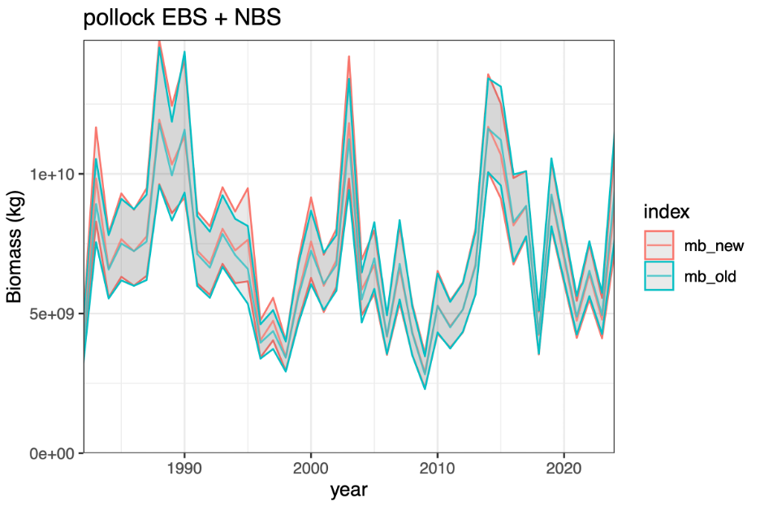

Figure 35: Model results comparing last year’s model with the revised sdmTMB model.

## Model-based Age Composition Methods

For model-based estimation of age compositions in the Bering Sea, we fitted observations of numerical abundance-at-age at each sampling location. This was made possible by applying a year-specific, region-specific (EBS and NBS) age-length key to records of numerical abundance and length composition. In subcategories (combinations of year, length, age, sex) that contained insufficient data, age composition was computed from length composition given a globally pooled age-length key.

We computed these estimates in the tinyVAST R package (https://vast-lib.github.io/tinyVAST; Thorson et al. (2024)), assuming a Poisson-link delta-model (Thorson 2018) involving two linear predictors, and a gamma distribution to model positive catch rates. We did not include any density covariates in estimation of age composition for consistency with models used in the previous assessments and due to computational limitations.

We estimated the spatial range assuming geometric isotropy (i.e, spatial autocorrelation declines with equal rates over distance in all cardinal directions). We used the same extrapolation grid as implemented for abundance indices, but here we modeled spatial and spatiotemporal fields with a mesh with a coarser spatial resolution than the index model, here using 50 “knots”. This reduction in the spatial resolution of the model, relative to that used for the abundance indices, was necessary due to the increased computational load of fitting multiple age categories.

The estimates of abundance at age were bias-corrected with the same method as the abundance index. We implemented the same diagnostics to check convergence and model fit as those used for the abundance index. Results compared favorably among methods (Figure 36).

Both the model-based bottom trawl index and age composition estimates were calculated using code in the AFSC GAP model-based indices GitHub repository (https://github.com/afsc-gap-products/model-based-indices). Design-based estimates of bottom trawl products were calculated using code in the gapindex R package (https://github.com/afsc-gap-products/gapindex).

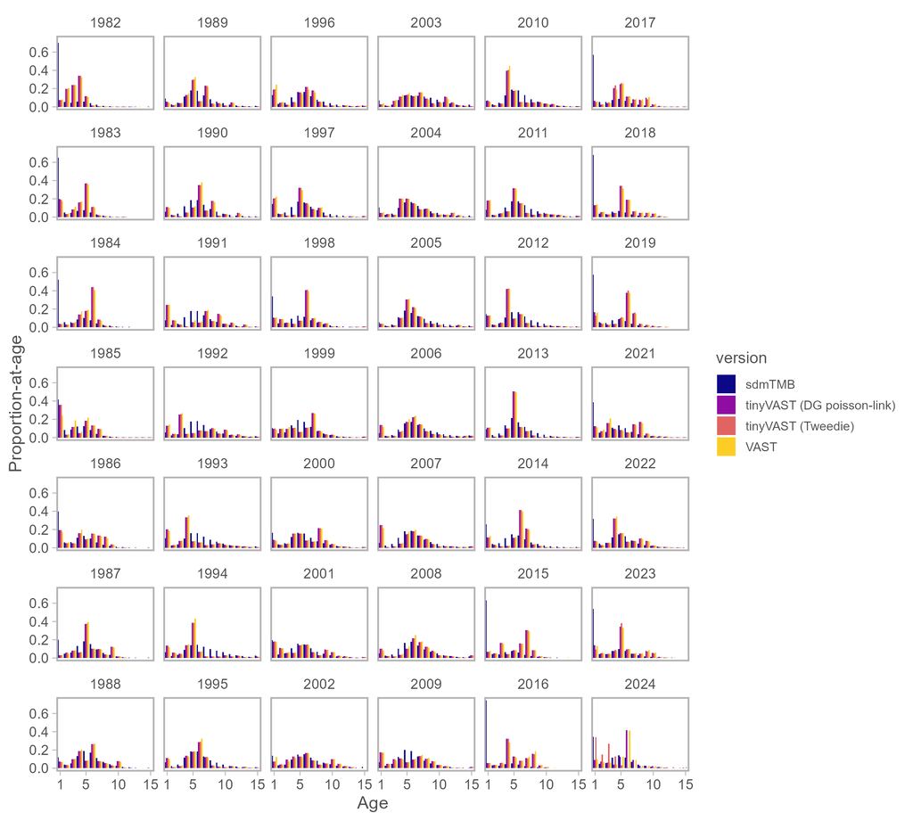

Figure 36: Model results comparing last year’s model with the revised sdmTMB model.

## References

Adams, Grant D., Kirstin K. Holsman, Steven J. Barbeaux, Martin W. Dorn, James N. Ianelli, Ingrid Spies, Ian J. Stewart, and André E. Punt. 2022. “An Ensemble Approach to Understand Predation Mortality for Groundfish in the Gulf of Alaska.” *Fisheries Research* 251: 106303. https://doi.org/https://doi.org/10.1016/j.fishres.2022.106303.

Anderson, S. C., E. J. Ward, P. A. English, and L. A. K. Barnett. 2022. “sdmTMB: An r Package for Fast, Flexible, and User-Friendly Generalized Linear Mixed Effects Models with Spatial and Spatiotemporal Random Fields.” *BioRxiv*, 2022–03. https://doi.org/10.1101/2022.03.24.485545.

Cheng, Matthew. 2025. *SPoCK: Spatial (s) Population (Po) Model with Connectivity (c) Across Generalized Komponents (k)*.

Cheng, Matthew L. H., Daniel R. Goethel, Peter-John F. Hulson, Michael J. Wilberg, Craig Marsh, and Curry J. Cunningham. 2025. “Misspecifying Sex-Structured Dynamics in Stock Assessment Models.” *Fish and Fisheries*, February, 1–19. https://doi.org/10.1111/faf.12891.

Dunn, K. P., and G. K. Smyth. 1996. “Randomized Quantile Residuals.” *Journal of Computational and Graphical Statistics* 5 (1): 1–10. https://doi.org/10.1080/10618600.1996.10474708.

Grandin, C. J., K. F. Johnson, A. M. Edwards, and A. M. Berger. 2024. “Status of the Pacific Hake (Whiting) Stock in U.S. And Canadian Waters in 2024.” Joint Technical Committee of the U.S.; Canada Pacific Hake/Whiting Agreement, National Marine Fisheries Service; Fisheries; Oceans Canada.

Hartig, Florian. 2021. *DHARMa: Residual Diagnostics for Hierarchical (Multi-Level / Mixed) Regression Models*. http://florianhartig.github.io/DHARMa/.

Helser, Thomas E., Irina Benson, Jason Erickson, Jordan Healy, Craig Kastelle, and Jonathan A. Short. 2019. “A Transformative Approach to Ageing Fish Otoliths Using Fourier Transform Near Infrared Spectroscopy: A Case Study of Eastern Bering Sea Walleye Pollock (*Gadus Chalcogrammus*).” *Canadian Journal of Fisheries and Aquatic Sciences* 76 (5): 780–89. https://doi.org/10.1139/cjfas-2018-0112.

Holsman, K. K., J. Ianelli, K. Shotwell, S. Barbeaux, K. Aydin, G. Adams, K. Kearney, A. Sulc, and S. Wassermann. 2024. “Climate-Enhanced Multispecies Stock Assessment for Walleye Pollock, Pacific Cod, and Arrowtooth Flounder in the Eastern Bering Sea.” Technical Report. Anchorage, AK: North Pacific Fishery Management Council. https://www.npfmc.org/wp-content/PDFdocuments/SAFE/2024/EBSmultispp.pdf.

Ianelli, Jim. 2025. *Ebswp: Facilitates Model Running for EBS Pollock*. http://afsc-assessments.github.io/EBSpollock/.

Jurado-Molina, J., P. A. Livingston, and J. N. Ianelli. 2005. “Incorporating Predation Interactions to a Statistical Catch-at-Age Model for a Predator-Prey System in the Eastern Bering Sea.” *Canadian Journal of Fisheries and Aquatic Sciences* 62 (8): 1865–73.

Methot, Richard D., and Chantell R. Wetzel. 2013. “Stock Synthesis: A Biological and Statistical Framework for Fish Stock Assessment and Fishery Management.” *Fisheries Research* 142 (May): 86–99. https://doi.org/10.1016/j.fishres.2012.10.012.

Nielsen, Anders, and Casper W. Berg. 2014. “Estimation of Time-Varying Selectivity in Stock Assessments Using State-Space Models.” *Fisheries Research* 158: 96–101. https://doi.org/10.1016/j.fishres.2014.01.014.

Nielsen, Anders, Niels T Hintzen, Henrik Mosegaard, Vanessa Trijoulet, and Casper W Berg. 2021. “Multi-Fleet State-Space Assessment Model Strengthens Confidence in Single-Fleet SAM and Provides Fleet-Specific Forecast Options.” *ICES Journal of Marine Science* 78 (6): 2043–52. https://doi.org/10.1093/icesjms/fsab078.

O’Leary, C. A., J. T. Thorson, J. N. Ianelli, and S. Kotwicki. 2020. “Adapting to Climate‐driven Distribution Shifts Using Model‐based Indices and Age Composition from Multiple Surveys in the Walleye Pollock (Gadus Chalcogrammus) Stock Assessment.” *Fisheries Oceanography* 29 (6): 541–57. https://doi.org/10.1111/fog.12494.

Punt, A. E., D. C. Smith, K. KrusicGolub, and S. Robertson. 2008. “Quantifying Age-Reading Error for Use in Fisheries Stock Assessments, with Application to Species in Australia’s Southern and Eastern Scalefish and Shark Fishery.” *Can. J. Fish. Aquat. Sci.* 65: 1991–2005.

Rohan, S. K., L. A. K. Barnett, and N. Charriere. 2022. “Evaluating Approaches to Estimating Mean Temperatures and Cold Pool Area from AFSC Bottom Trawl Surveys of the Eastern Bering Sea.” Tech. Mem. NMFS-AFSC-456. U.S. Dep. Commer., NOAA. https://doi.org/10.25923/1wwh-q418.

Stock, Brian C., and Timothy J. Miller. 2021. “The Woods Hole Assessment Model (WHAM): A General State-Space Assessment Framework That Incorporates Time- and Age-Varying Processes via Random Effects and Links to Environmental Covariates.” *Fisheries Research* 240 (August): 105967. https://doi.org/10.1016/j.fishres.2021.105967.

Thorson, J. T. 2018. “Three Problems with the Conventional Delta-Model for Biomass Sampling Data, and a Computationally Efficient Alternative.” *Canadian Journal of Fisheries and Aquatic Sciences* 75 (9): 1369–82. https://doi.org/10.1139/cjfas-2017-0266.

———. 2019. “Measuring the Impact of Oceanographic Indices on Species Distribution Shifts: The Spatially Varying Effect of Cold‐pool Extent in the Eastern Bering Sea.” *Limnology and Oceanography* 64 (6): 2632–45. https://doi.org/10.1002/lno.11238.

Thorson, J. T., S. C. Anderson, P. Goddard, and C. N. Rooper. 2024. “tinyVAST: R Package with an Expressive Interface to Specify Lagged and Simultaneous Effects in Multivariate Spatio-Temporal Models.” *arXiv Preprint* arXiv:2401.10193.

Thorson, J. T., and K. Kristensen. 2016. “Implementing a Generic Method for Bias Correction in Statistical Models Using Random Effects, with Spatial and Population Dynamics Examples.” *Fisheries Research* 175: 66–74. https://doi.org/10.1016/j.fishres.2015.11.016.

Trijoulet, Vanessa, Gavin Fay, and Timothy J. Miller. 2020. “Performance of a State-Space Multispecies Model: What Are the Consequences of Ignoring Predation and Process Errors in Stock Assessments?” *Journal of Applied Ecology* 57 (1): 121–35. https://doi.org/https://doi.org/10.1111/1365-2664.13515.